# Data cleaning- Justin photos

```r
library(lubridate)
library(tidyverse)
library(ggplot2)
```

Pull Justin’s measurements

```r
NJ_data_final_JD <- read_csv("~/Documents/OneDrive - aguadilla.inter.edu/BS Microbiology Inter/Internship and opportunities/RISE Internship/2022-croakerlarvae-rise/data/NJ_data_final_JD.csv")
View(NJ_data_final_JD)
```

Pull 1995 measurements

```r
atlantic_croaker1995 <- read_csv("data/atlantic_croaker1995.csv")
```

Pull the csv files with Justin’s photos which I measured The odd rows represent measurements from the lateral side of the fish, and the even rows represent measurements from the dorsal side of the fish

```r
atlantic_croaker_2017_Jmeasurements <- read_csv("~/Documents/OneDrive - aguadilla.inter.edu/BS Microbiology Inter/Internship and opportunities/RISE Internship/2022-croakerlarvae-rise/data/atlantic_croaker_2017_Jmeasurements.csv")
View(atlantic_croaker_2017_Jmeasurements)
```

Create column to then merge them

```r
atlantic_croaker2017_justin_measurements <- atlantic_croaker_2017_Jmeasurements %>%
  mutate(spp_num=rep(1:(nrow(atlantic_croaker_2017_Jmeasurements)/2), each=2))

#merged the two columns
atlantic_croaker2017JM <- atlantic_croaker2017_justin_measurements %>%
  group_by(spp_num) %>%
  summarise(across(2:14,~ max (.x, na.rm=TRUE)))

#copying linked image file names from ObjectJ
linked_image_names <- c(seq(272,290, by = 1), 314)
```

Add the code (id name of each fish) to the sheet I created

```r
atlantic_croaker2017J_M <- atlantic_croaker2017JM %>%
  mutate(Code=linked_image_names)
```

Add _Justin to the measurements

```r
atlantic2017_justin <- NJ_data_final_JD %>%
  rename_with(~ paste(.x, "_Justin", sep=""),.cols=c(2:14))
```

Merge columns together

```r
atlantic_croaker2017 <- inner_join(atlantic2017_justin, atlantic_croaker2017J_M, by="Code")
```

Code used: colnames(atlantic_croaker2017J_M) “Standardlength” “Totallength” “Depthatpec” “Depthatanus”  
“Pulsearea” “Musclearea” “Bodyarea” “Cauddepth” “Caudheight”  
“Caudarea” “Bodywidth” “Interoctdistance” “Eyediameter”

#Start creating the linear models

##Standard Length

```r
SL_linear_model <- lm(Standardlength ~ standardlength_Justin, atlantic_croaker2017)
summary(SL_linear_model)
```

```
Call:
lm(formula = Standardlength ~ standardlength_Justin, data = atlantic_croaker2017)

Residuals:
     Min       1Q   Median       3Q      Max
-1.32649 -0.21956 -0.01143  0.32500  1.42896

Coefficients:
                      Estimate Std. Error t value Pr(>|t|)
(Intercept)            -0.9465     0.8856  -1.069    0.299
standardlength_Justin   1.1178     0.1037  10.779 2.78e-09 ***
---
Signif. codes:  0 ‘***’ 0.001 ‘**’ 0.01 ‘*’ 0.05 ‘.’ 0.1 ‘ ’ 1

Residual standard error: 0.5897 on 18 degrees of freedom
Multiple R-squared:  0.8659,    Adjusted R-squared:  0.8584
F-statistic: 116.2 on 1 and 18 DF,  p-value: 2.78e-09
```

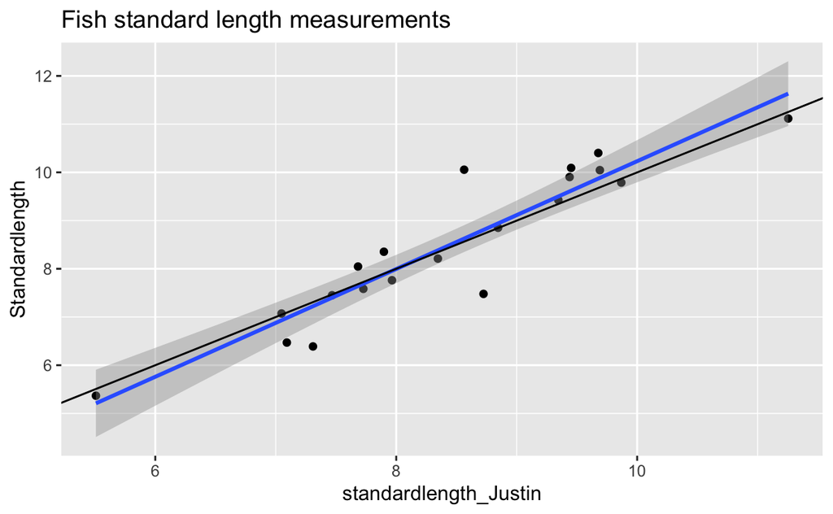

```r
#make a ggplot
ggplot(atlantic_croaker2017) +
  geom_point(aes(x=standardlength_Justin, y=Standardlength)) +
  geom_smooth(aes(x=standardlength_Justin, y=Standardlength), method = "lm")+
  geom_abline(intercept=0, slope=1) +
  ggtitle("Fish standard length measurements")
```

Information recorded from the linear model y=mx+b m= 1.1178x-0.9465 R-squared= 0.8659 P value= 2.78e-09

##Total Lenght

```r
TL_linear_model <- lm(Totallength ~ totallength_Justin, atlantic_croaker2017)
summary(TL_linear_model)
```

```
Call:
lm(formula = Totallength ~ totallength_Justin, data = atlantic_croaker2017)

Residuals:
     Min       1Q   Median       3Q      Max
-1.36696 -0.32866  0.01961  0.40618  1.75677

Coefficients:
                   Estimate Std. Error t value Pr(>|t|)
(Intercept)        -1.27534    1.05171  -1.213    0.241
totallength_Justin  1.11796    0.09893  11.300 1.32e-09 ***
---
Signif. codes:  0 ‘***’ 0.001 ‘**’ 0.01 ‘*’ 0.05 ‘.’ 0.1 ‘ ’ 1

Residual standard error: 0.7053 on 18 degrees of freedom
Multiple R-squared:  0.8764,    Adjusted R-squared:  0.8696
F-statistic: 127.7 on 1 and 18 DF,  p-value: 1.32e-09
```

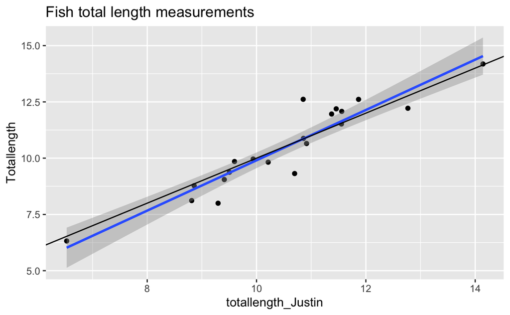

```r
#make a ggplot
ggplot(atlantic_croaker2017) +
  geom_point(aes(x=totallength_Justin, y=Totallength)) +
  geom_smooth(aes(x=totallength_Justin, y=Totallength), method = "lm") +
  geom_abline(intercept = 0, slope = 1) +
  ggtitle("Fish total length measurements")
```

y=mx+b m= 1.11796-1.27534 R-squared= 0.8764 P value= 1.32e-09

##Depth Pectoral

```r
DP_linear_model <- lm(Depthatpec ~ bodydepthpectoral_Justin, atlantic_croaker2017)
summary(DP_linear_model)
```

```
Call:
lm(formula = Depthatpec ~ bodydepthpectoral_Justin, data = atlantic_croaker2017)

Residuals:
     Min       1Q   Median       3Q      Max
-0.25670 -0.07174  0.01708  0.08067  0.22719

Coefficients:
                         Estimate Std. Error t value Pr(>|t|)
(Intercept)              -0.45649    0.19609  -2.328   0.0318 *
bodydepthpectoral_Justin  1.16066    0.08265  14.043 3.86e-11 ***
---
Signif. codes:  0 ‘***’ 0.001 ‘**’ 0.01 ‘*’ 0.05 ‘.’ 0.1 ‘ ’ 1

Residual standard error: 0.1316 on 18 degrees of freedom
Multiple R-squared:  0.9164,    Adjusted R-squared:  0.9117
F-statistic: 197.2 on 1 and 18 DF,  p-value: 3.863e-11
```

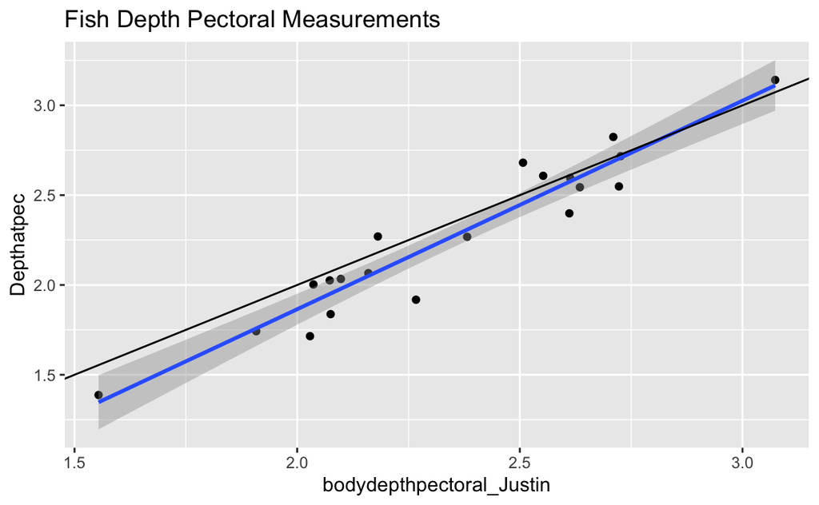

```r
#make a ggplot
ggplot(atlantic_croaker2017) +
  geom_point(aes(x=bodydepthpectoral_Justin, y=Depthatpec))+
  geom_smooth(aes(x=bodydepthpectoral_Justin, y=Depthatpec), method = "lm") +
  geom_abline(intercept = 0, slope = 1) +
  ggtitle("Fish Depth Pectoral Measurements")
```

y=mx+b m= 1.16066-0.45649 R-squared=0.9164 P value=3.86e-11

##Depth Anus

```r
DA_linear_model <- lm(Depthatanus ~ bodydepthanus_Justin, atlantic_croaker2017)
summary(DA_linear_model)
```

```
Call:
lm(formula = Depthatanus ~ bodydepthanus_Justin, data = atlantic_croaker2017)

Residuals:
     Min       1Q   Median       3Q      Max
-0.25339 -0.08029  0.01626  0.08833  0.19448

Coefficients:
                     Estimate Std. Error t value Pr(>|t|)
(Intercept)           -0.3047     0.1892  -1.611    0.125
bodydepthanus_Justin   0.9988     0.1011   9.874 1.09e-08 ***
---
Signif. codes:  0 ‘***’ 0.001 ‘**’ 0.01 ‘*’ 0.05 ‘.’ 0.1 ‘ ’ 1

Residual standard error: 0.1298 on 18 degrees of freedom
Multiple R-squared:  0.8441,    Adjusted R-squared:  0.8355
F-statistic:  97.5 on 1 and 18 DF,  p-value: 1.085e-08
```

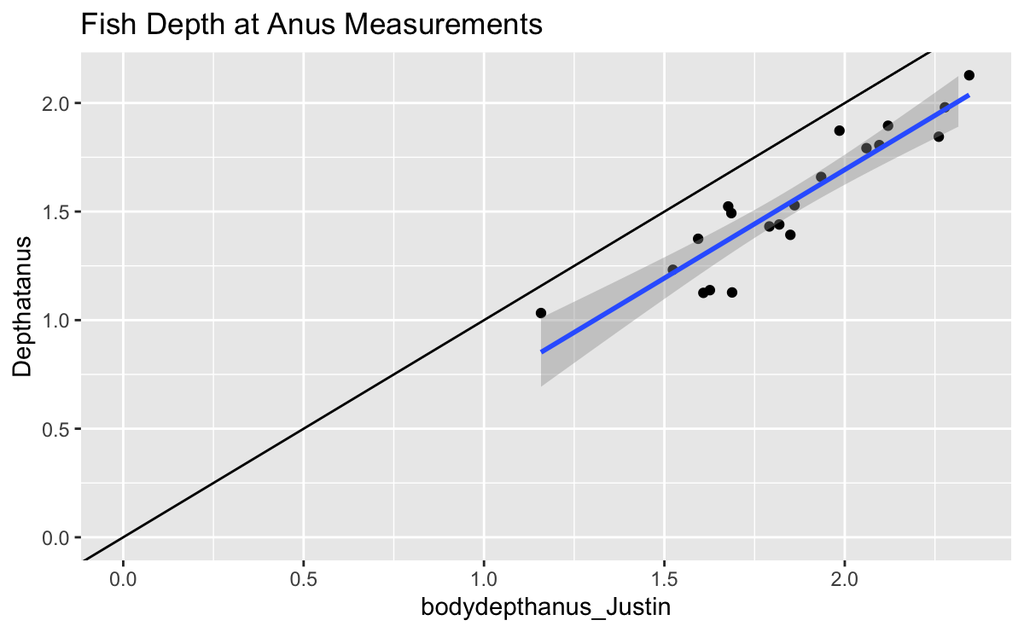

```r
#make a ggplot
ggplot(atlantic_croaker2017) +
  geom_point(aes(x= bodydepthanus_Justin, y=Depthatanus)) +
  geom_smooth(aes(x= bodydepthanus_Justin, y=Depthatanus), method = "lm")+
  geom_abline(intercept = 0, slope=1) +
  lims(x=c(0,max(atlantic_croaker2017$bodydepthanus_Justin)),y=c(0, max(atlantic_croaker2017$Depthatanus))) +
  ggtitle("Fish Depth at Anus Measurements")
```

y=mx+b m=0.9988-0.3047 R-squared=0.8441 P value=1.09e-08

##Propulsive Area

```r
PA_linear_model <- lm(Pulsearea ~ propulsivearea_Justin, atlantic_croaker2017)
summary(PA_linear_model)
```

```
Call:
lm(formula = Pulsearea ~ propulsivearea_Justin, data = atlantic_croaker2017)

Residuals:
    Min      1Q  Median      3Q     Max
-2.9156 -0.6375 -0.1052  1.0733  2.4564

Coefficients:
                      Estimate Std. Error t value Pr(>|t|)
(Intercept)             -1.847      1.221  -1.513    0.148
propulsivearea_Justin    1.124      0.107  10.508 4.14e-09 ***
---
Signif. codes:  0 ‘***’ 0.001 ‘**’ 0.01 ‘*’ 0.05 ‘.’ 0.1 ‘ ’ 1

Residual standard error: 1.392 on 18 degrees of freedom
Multiple R-squared:  0.8598,    Adjusted R-squared:  0.8521
F-statistic: 110.4 on 1 and 18 DF,  p-value: 4.141e-09
```

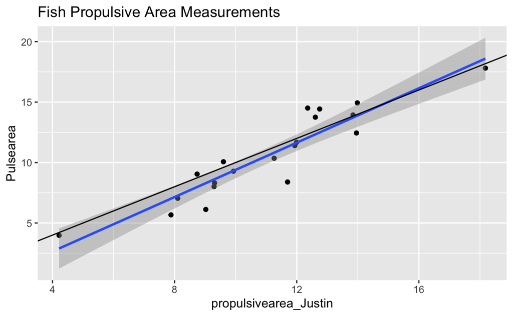

```r
#make a ggplot
ggplot(atlantic_croaker2017)+
  geom_point(aes(x=propulsivearea_Justin, y=Pulsearea)) +
  geom_smooth(aes(x=propulsivearea_Justin, y=Pulsearea), method = "lm") +
  geom_abline(intercept = 0, slope = 1) +
  ggtitle("Fish Propulsive Area Measurements")
```

y=mx+b m= 1.124-1.847 R-squared= 0.8598 P value= 4.14e-09

##Muscle Area

```r
MA_linear_model <- lm(Musclearea ~ musclearea_Justin, atlantic_croaker2017)
summary(MA_linear_model)
```

```
Call:
lm(formula = Musclearea ~ musclearea_Justin, data = atlantic_croaker2017)

Residuals:
     Min       1Q   Median       3Q      Max
-1.10422 -0.63704 -0.03983  0.42707  1.71999

Coefficients:
                  Estimate Std. Error t value Pr(>|t|)
(Intercept)       -0.82451    0.58846  -1.401    0.178
musclearea_Justin  1.12668    0.08463  13.313 9.33e-11 ***
---
Signif. codes:  0 ‘***’ 0.001 ‘**’ 0.01 ‘*’ 0.05 ‘.’ 0.1 ‘ ’ 1

Residual standard error: 0.8021 on 18 degrees of freedom
Multiple R-squared:  0.9078,    Adjusted R-squared:  0.9027
F-statistic: 177.2 on 1 and 18 DF,  p-value: 9.327e-11
```

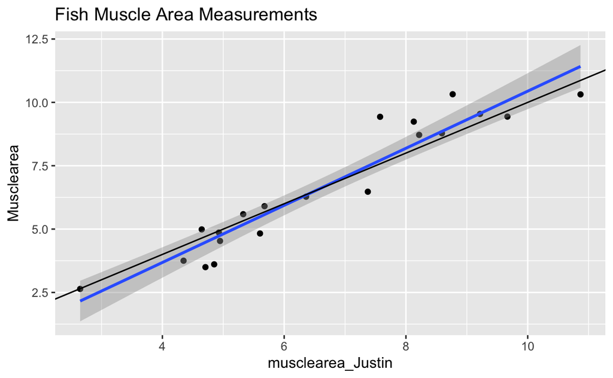

```r
#make a ggplot
ggplot(atlantic_croaker2017) +
  geom_point(aes(x=musclearea_Justin, y=Musclearea)) +
  geom_smooth(aes(x=musclearea_Justin, y=Musclearea), method = "lm") +
  geom_abline(intercept = 0, slope = 1) +
  ggtitle("Fish Muscle Area Measurements")
```

y=mx+b m= 1.12668-0.82451 R-squared= 0.9078 P value= 9.33e-11

##Body Area

```r
BA_linear_model <- lm(Bodyarea ~ bodyarea_Justin, atlantic_croaker2017)
summary(BA_linear_model)
```

```
Call:
lm(formula = Bodyarea ~ bodyarea_Justin, data = atlantic_croaker2017)

Residuals:
    Min      1Q  Median      3Q     Max
-3.6390 -0.7574 -0.0837  1.1826  4.0432

Coefficients:
                Estimate Std. Error t value Pr(>|t|)
(Intercept)     -1.04866    1.42470  -0.736    0.471
bodyarea_Justin  1.08743    0.09877  11.009 1.99e-09 ***
---
Signif. codes:  0 ‘***’ 0.001 ‘**’ 0.01 ‘*’ 0.05 ‘.’ 0.1 ‘ ’ 1

Residual standard error: 1.82 on 18 degrees of freedom
Multiple R-squared:  0.8707,    Adjusted R-squared:  0.8635
F-statistic: 121.2 on 1 and 18 DF,  p-value: 1.994e-09
```

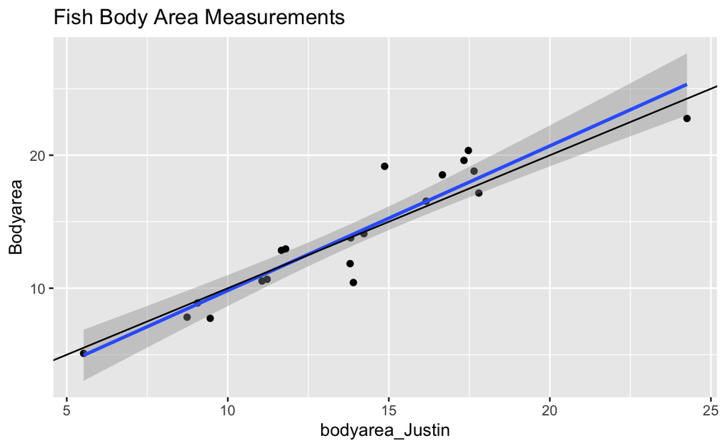

```r
#make a ggplot
ggplot(atlantic_croaker2017) +
  geom_point(aes(x=bodyarea_Justin, y=Bodyarea)) +
  geom_smooth(aes(x=bodyarea_Justin, y=Bodyarea), method="lm") +
  geom_abline(intercept = 0, slope = 1) +
  ggtitle("Fish Body Area Measurements")
```

y=mx+b m=1.08743-1.04866 R-squared=0.8707 P value=1.99e-09

##Caudal Peduncle Depth

```r
CP_linear_model <- lm(Cauddepth ~ caudalpeduncledepth_Justin, atlantic_croaker2017)
summary(CP_linear_model)
```

```
Call:
lm(formula = Cauddepth ~ caudalpeduncledepth_Justin, data = atlantic_croaker2017)

Residuals:
     Min       1Q   Median       3Q      Max
-0.07132 -0.04476 -0.01766  0.03108  0.18050

Coefficients:
                           Estimate Std. Error t value Pr(>|t|)
(Intercept)                0.006023   0.084456   0.071    0.944
caudalpeduncledepth_Justin 1.029639   0.127475   8.077 2.14e-07 ***
---
Signif. codes:  0 ‘***’ 0.001 ‘**’ 0.01 ‘*’ 0.05 ‘.’ 0.1 ‘ ’ 1

Residual standard error: 0.06523 on 18 degrees of freedom
Multiple R-squared:  0.7838,    Adjusted R-squared:  0.7717
F-statistic: 65.24 on 1 and 18 DF,  p-value: 2.137e-07
```

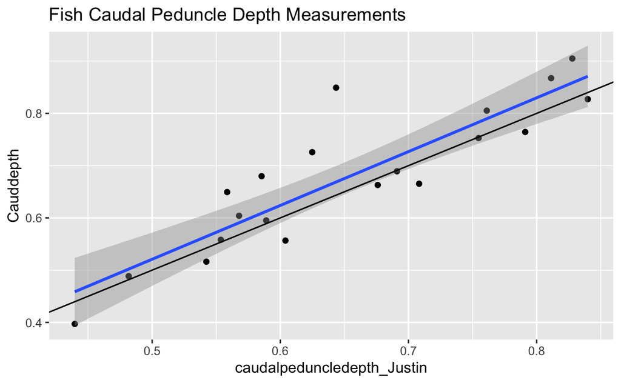

```r
#make a ggplot
ggplot(atlantic_croaker2017) +
  geom_point(aes(x=caudalpeduncledepth_Justin, y=Cauddepth)) +
  geom_smooth(aes(x=caudalpeduncledepth_Justin, y=Cauddepth), method = "lm") +
  geom_abline(intercept = 0, slope = 1) +
  ggtitle("Fish Caudal Peduncle Depth Measurements")
```

y=mx+b m= 1.029639 + 0.006023 R-squared= 0.7838 P value= 2.14e-07

##Caudal Fin Height

```r
CF_linear_model <- lm(Caudheight ~ caudalfinheight_Justin, atlantic_croaker2017)
summary(CF_linear_model)
```

```
Call:
lm(formula = Caudheight ~ caudalfinheight_Justin, data = atlantic_croaker2017)

Residuals:
      Min        1Q    Median        3Q       Max
-0.204384 -0.066542  0.008811  0.043558  0.247090

Coefficients:
                       Estimate Std. Error t value Pr(>|t|)
(Intercept)              0.2973     0.1495   1.989   0.0621 .
caudalfinheight_Justin   0.6657     0.1325   5.025  8.8e-05 ***
---
Signif. codes:  0 ‘***’ 0.001 ‘**’ 0.01 ‘*’ 0.05 ‘.’ 0.1 ‘ ’ 1

Residual standard error: 0.1178 on 18 degrees of freedom
Multiple R-squared:  0.5838,    Adjusted R-squared:  0.5607
F-statistic: 25.25 on 1 and 18 DF,  p-value: 8.795e-05
```

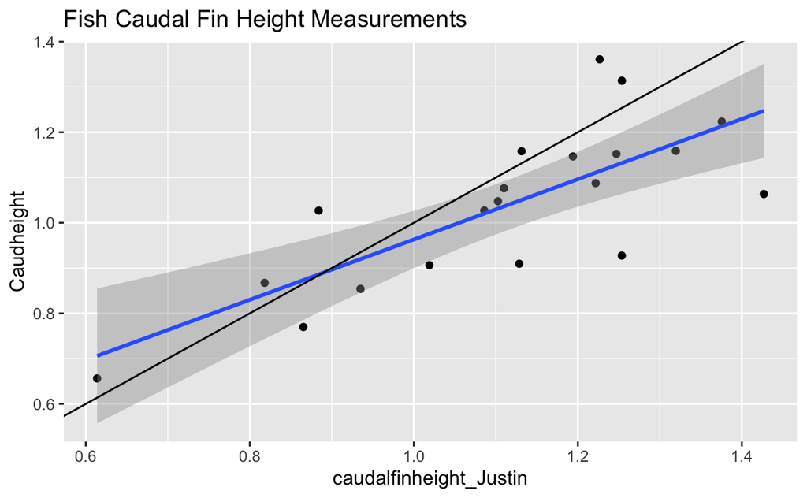

```r
#make a ggplot
ggplot(atlantic_croaker2017) +
  geom_point(aes(x=caudalfinheight_Justin, y=Caudheight)) +
  geom_smooth(aes(x=caudalfinheight_Justin, y=Caudheight), method = "lm") +
  geom_abline(intercept = 0, slope = 1) +
  ggtitle("Fish Caudal Fin Height Measurements")
```

y=mx+b m= 0.6657 + 0.2973 R-squared= 0.5838 P value= 8.8e-05

##Caudal Fin Area

```r
CA_linear_model <- lm(Caudarea ~ caudalfinarea_Justin, atlantic_croaker2017)
summary(CA_linear_model)
```

```
Call:
lm(formula = Caudarea ~ caudalfinarea_Justin, data = atlantic_croaker2017)

Residuals:
     Min       1Q   Median       3Q      Max
-0.53442 -0.38613  0.02864  0.18341  1.37750

Coefficients:
                     Estimate Std. Error t value Pr(>|t|)
(Intercept)            0.3727     0.3412   1.092 0.289129
caudalfinarea_Justin   0.6457     0.1441   4.481 0.000289 ***
---
Signif. codes:  0 ‘***’ 0.001 ‘**’ 0.01 ‘*’ 0.05 ‘.’ 0.1 ‘ ’ 1

Residual standard error: 0.4601 on 18 degrees of freedom
Multiple R-squared:  0.5273,    Adjusted R-squared:  0.501
F-statistic: 20.08 on 1 and 18 DF,  p-value: 0.000289
```

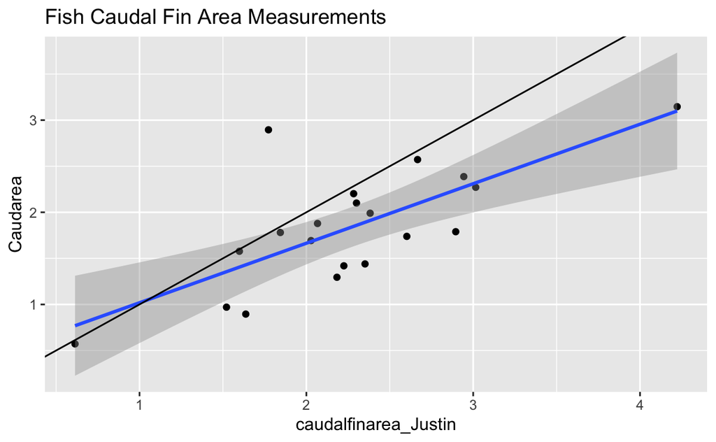

```r
#make a ggplot
ggplot(atlantic_croaker2017) +
  geom_point(aes(x=caudalfinarea_Justin, y=Caudarea)) +
  geom_smooth(aes(x=caudalfinarea_Justin, y=Caudarea), method = "lm") +
  geom_abline(intercept = 0, slope = 1) +
  ggtitle("Fish Caudal Fin Area Measurements")
```

y=mx+b m=0.6457 + 0.3727 R-squared=0.5273 P value= 0.000289

##Body Width

```r
BW_linear_model <- lm(Bodywidth ~ bodywidth_Justin, atlantic_croaker2017)
summary(BW_linear_model)
```

```
Call:
lm(formula = Bodywidth ~ bodywidth_Justin, data = atlantic_croaker2017)

Residuals:
     Min       1Q   Median       3Q      Max
-0.17355 -0.09516  0.01161  0.06558  0.19998

Coefficients:
                 Estimate Std. Error t value Pr(>|t|)
(Intercept)       -0.2114     0.1290  -1.639    0.119
bodywidth_Justin   0.6886     0.1177   5.849 1.54e-05 ***
---
Signif. codes:  0 ‘***’ 0.001 ‘**’ 0.01 ‘*’ 0.05 ‘.’ 0.1 ‘ ’ 1

Residual standard error: 0.105 on 18 degrees of freedom
Multiple R-squared:  0.6553,    Adjusted R-squared:  0.6361
F-statistic: 34.21 on 1 and 18 DF,  p-value: 1.537e-05
```

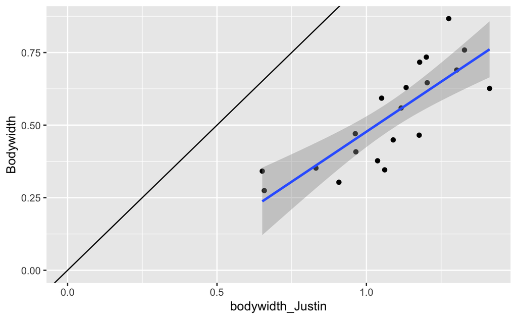

```r
#make a ggplot
ggplot(atlantic_croaker2017) +
  geom_point(aes(x=bodywidth_Justin, y=Bodywidth)) +
  geom_smooth(aes(x=bodywidth_Justin, y=Bodywidth), method = "lm") +
  geom_abline(intercept = 0, slope = 1) +
  lims(x=c(0, max(atlantic_croaker2017$bodywidth_Justin)), y=c(0, max(atlantic_croaker2017$Bodywidth)))
```

```r
  ggtitle("Fish Body Width Measurements")
```

```
$title
[1] "Fish Body Width Measurements"

attr(,"class")
[1] "labels"
```

y=mx+b m=0.6886-0.2114 R-squared= 0.6553 P value=1.54e-05

##Eye Diameter

```r
ED_linear_model <- lm(Eyediameter ~ eyediameter_Justin, atlantic_croaker2017)
summary(ED_linear_model)
```

```
Call:
lm(formula = Eyediameter ~ eyediameter_Justin, data = atlantic_croaker2017)

Residuals:
      Min        1Q    Median        3Q       Max
-0.113954 -0.034477 -0.001098  0.046013  0.131951

Coefficients:
                   Estimate Std. Error t value Pr(>|t|)
(Intercept)        -0.09974    0.10026  -0.995    0.333
eyediameter_Justin  1.13797    0.16736   6.800 2.29e-06 ***
---
Signif. codes:  0 ‘***’ 0.001 ‘**’ 0.01 ‘*’ 0.05 ‘.’ 0.1 ‘ ’ 1

Residual standard error: 0.06411 on 18 degrees of freedom
Multiple R-squared:  0.7198,    Adjusted R-squared:  0.7042
F-statistic: 46.23 on 1 and 18 DF,  p-value: 2.286e-06
```

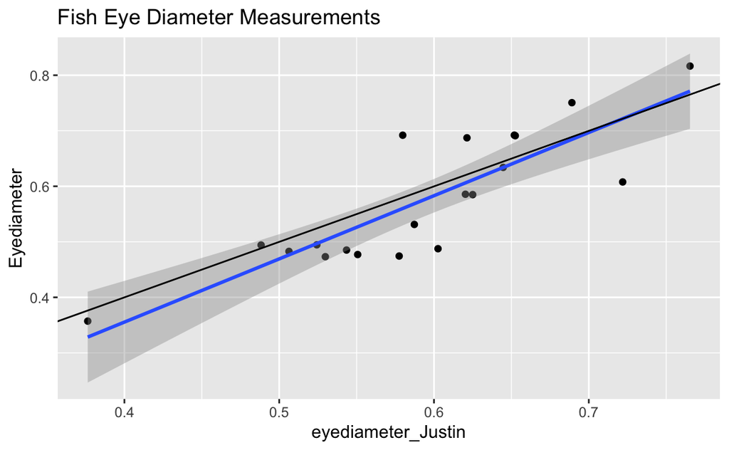

```r
#make a ggplot
ggplot(atlantic_croaker2017) +
  geom_point(aes(x=eyediameter_Justin, y=Eyediameter)) +
  geom_smooth(aes(x=eyediameter_Justin, y=Eyediameter), method = "lm") +
  geom_abline(intercept = 0, slope = 1) +
  ggtitle("Fish Eye Diameter Measurements")
```

y=mx+b m= 1.13797-0.09974 R-squared=0.7198 P value= 2.29e-06

##Interorbital Width

```r
IW_linear_model <- lm(Interoctdistance ~ interorbitalwidth_Justin, atlantic_croaker2017)
summary(IW_linear_model)
```

```
Call:
lm(formula = Interoctdistance ~ interorbitalwidth_Justin, data = atlantic_croaker2017)

Residuals:
     Min       1Q   Median       3Q      Max
-0.12955 -0.07293  0.01457  0.05219  0.13372

Coefficients:
                         Estimate Std. Error t value Pr(>|t|)
(Intercept)                0.1275     0.1250   1.020  0.32138
interorbitalwidth_Justin   0.9007     0.1918   4.695  0.00018 ***
---
Signif. codes:  0 ‘***’ 0.001 ‘**’ 0.01 ‘*’ 0.05 ‘.’ 0.1 ‘ ’ 1

Residual standard error: 0.08856 on 18 degrees of freedom
Multiple R-squared:  0.5505,    Adjusted R-squared:  0.5255
F-statistic: 22.05 on 1 and 18 DF,  p-value: 0.0001803
```

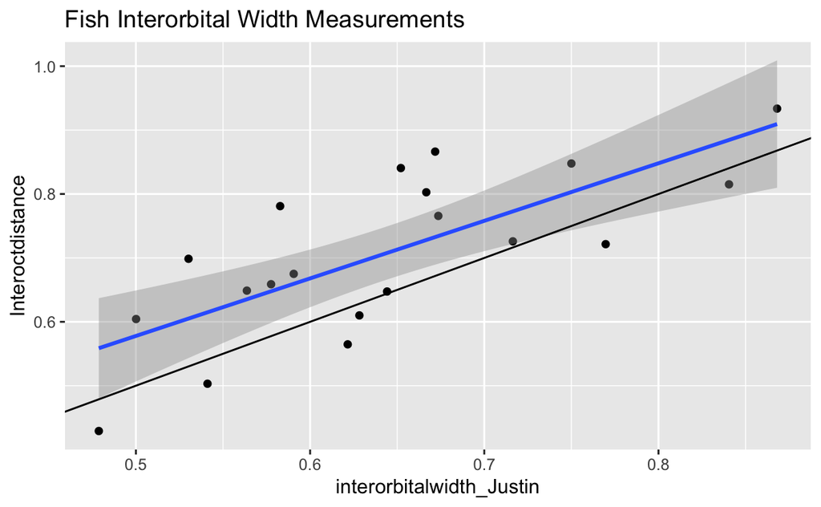

```r
#make a ggplot
ggplot(atlantic_croaker2017) +
  geom_point(aes(x=interorbitalwidth_Justin, y=Interoctdistance)) +
  geom_smooth(aes(x=interorbitalwidth_Justin, y=Interoctdistance), method = "lm") +
  geom_abline(intercept = 0, slope = 1) +
  ggtitle("Fish Interorbital Width Measurements")
```

y=mx+b m= 0.9007 + 0.1275 R-squared= 0.5505 P value= 0.00018

# Converting Justin’s measurements from 2017 to Jesenia’s measurements

colnames(atlantic_croaker1995) [1] “spp_num” “Standardlength” “Totallength” “Depthatpec” “Depthatanus”  
[6] “Pulsearea” “Musclearea” “Bodyarea” “Cauddepth” “Caudheight”  
[11] “Caudarea” “Bodywidth” “Interoctdistance” “Eyediameter” “Code”  
[16] “Spp” “Tow_date” “Tow_ID” “Tow_num” “Picture Date”  
[21] “Time Start-End” “Notes” “Measurements” “Genus” “Species”  
[26] “Survey” “Preserve” “Number” “Location”

colnames(atlantic2017_justin) [1] “Code” “standardlength_Justin”  
[3] “totallength_Justin” “bodydepthpectoral_Justin”  
[5] “bodydepthanus_Justin” “propulsivearea_Justin”  
[7] “bodyarea_Justin” “musclearea_Justin”  
[9] “eyediameter_Justin” “caudalpeduncledepth_Justin” [11] “caudalfinheight_Justin” “caudalfinarea_Justin”  
[13] “bodywidth_Justin” “interorbitalwidth_Justin”  
[15] “Date” “region”  
[17] “SST”

```r
#Format
at_croaker2017 <- atlantic2017_justin %>%
  mutate(Standardlength= 1.1178*standardlength_Justin - 0.9465,
         Totallength=1.11796*totallength_Justin -1.27534,
         Depthatpec= 1.16066*bodydepthpectoral_Justin -0.45649,
         Depthatanus= 0.9988*bodydepthanus_Justin -0.3047,
         Pulsearea= 1.124*propulsivearea_Justin -1.847,
         Musclearea=1.12668*musclearea_Justin -0.82451,
         Bodyarea= 1.08743*bodyarea_Justin -1.04866,
         Cauddepth= 1.029639*caudalpeduncledepth_Justin + 0.006023,
         Caudheight= 0.6657*caudalfinheight_Justin + 0.2973,
         Caudarea= 0.6457*caudalfinarea_Justin + 0.3727,
         Bodywidth= 0.6886*bodywidth_Justin -0.2114,
         Eyediameter= 1.13797*eyediameter_Justin -0.09974,
         Interoctdistance= 0.9007*interorbitalwidth_Justin + 0.1275,
         Spp= "Micropogonias undulatus") %>%
  rename(Tow_date=Date) %>%
  select(Spp, Tow_date, Code, Standardlength, Totallength, Depthatpec, Depthatanus, Bodyarea, Musclearea, Pulsearea, Bodywidth, Caudarea, Cauddepth, Caudheight, Eyediameter, Interoctdistance, SST)

view(at_croaker2017)
```

colnames(atlantic_croaker1995) [1] “spp_num” “Standardlength” “Totallength” “Depthatpec” “Depthatanus”  
[6] “Pulsearea” “Musclearea” “Bodyarea” “Cauddepth” “Caudheight”  
[11] “Caudarea” “Bodywidth” “Interoctdistance” “Eyediameter” “Code”  
[16] “Spp” “Tow_date” “Tow_ID” “Tow_num” “Picture Date”  
[21] “Time Start-End” “Notes” “Measurements” “Genus” “Species”  
[26] “Survey.x” “Preserve” “Number” “Location.x” “…30”  
[31] “Survey.y” “Location.y” “Time” “Sudo” “Bodo”  
[36] “SuSal” “BoSal” “SuTemp” “BoTemp” “Tide”  
[41] “Depth” “LatDeg” “Latitude” “LongDeg” “LONGITUD”  
[46] “Secchi” “SuPH” “BoPH” “Northing” “Easting”  
[51] “UTM” “Edit” “year”

colnames(at_croaker2017) [1] “Spp” “Tow_date” “Code” “Standardlength” “Totallength”  
[6] “Depthatpec” “Depthatanus” “Bodyarea” “Musclearea” “Pulsearea”  
[11] “Bodywidth” “Caudarea” “Cauddepth” “Caudheight” “Eyediameter”  
[16] “Interoctdistance” “SST”

Create a new file that has the temperature in it

```r
atlantic_1995_croaker <- atlantic_croaker1995 %>%
  rename(SST=SuTemp) %>%
  select(Spp, Tow_date, Code, Standardlength, Totallength, Depthatpec, Depthatanus, Bodyarea, Musclearea, Pulsearea, Bodywidth, Caudarea, Cauddepth, Caudheight, Eyediameter, Interoctdistance, SST)
View(atlantic_1995_croaker)
```

See if both columns match names

```r
colnames(atlantic_1995_croaker)==colnames(at_croaker2017)
```

```
 [1] TRUE TRUE TRUE TRUE TRUE TRUE TRUE TRUE TRUE TRUE TRUE TRUE TRUE TRUE TRUE
[16] TRUE TRUE
```

```r
atlantic_croaker_final <- rbind(atlantic_1995_croaker, at_croaker2017)
view(atlantic_croaker_final)
```

Save data in files

```r
write_csv(atlantic_croaker_final, file= "data/atlantic_croaker_final.csv")
```